# Diversity indices examples

Jonas Gehrlein

25 okt 2018

Jeg går igennem nogle eksempler på hvordan diversitetsindeks opfører sig ved forskellige abundanser for artsrigdom,shannon og simpson. Hvor vi ser på hvis der er lige mange af hver art, hvis en eller få arter udgår størstedelen af abundansen og hvis en minoritet har en mindre abundans end resten for både 10 og 20 arter. Derudover starter jeg med forskellen på diversitetsindeks og diversiteten. F.eks er radius af en kugle et indeks for volumen, men det er ikke volumen. på samme måde kan man have en indeks for diversiteten som ikke er selve diversiteten

Først starter vi med det tilfælde hvor der er lige mange af hver art og der er ti arter under disse tilfælde er diversiteten for alle alpha diversitetsindex lig med antallet af arter og finder shannon og simpson index for det tilfælde.

Her er artsrigdom, shannon og simpson det samme.

```
## [1] "Shannon index"    "2.30258509299405"
```

Dette sker ikke hvis man bruger det rå shannon index siden at det er en entropi og ikke en diversitet. Forholdet mellem entropien og antallet af elementer i et system er at $e^H = D$ så hvis vi tager eksponenten af shannon får vi en diversitet. dette er vigtigt for en fordopling i antallet af ligeligt fordelte arter fordopler ikke indekset.

[output not shown]

Men hvis vi tager eksponenten af entropien ser vi fordoplingen og den kan direkte sammenlignes med artsrigdommen

Siden at alle arter er lige fordelte er alle diversitets index lig med artsrigdommen Det samme gør sig gældene for simpson index. Her skal man tage 1/simpson

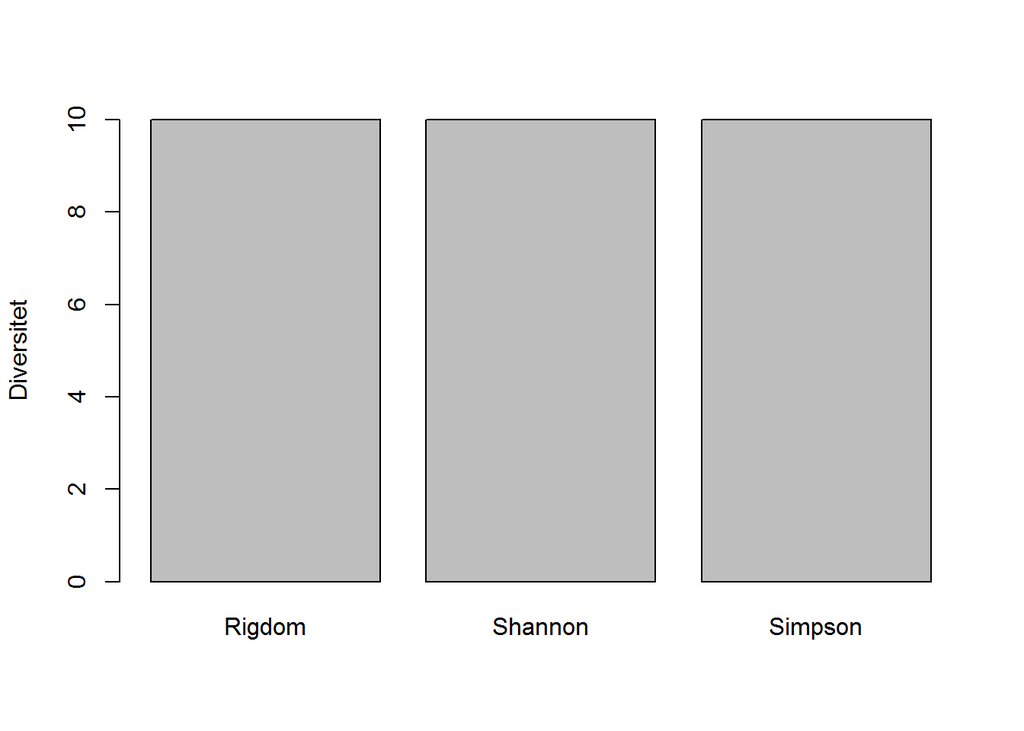

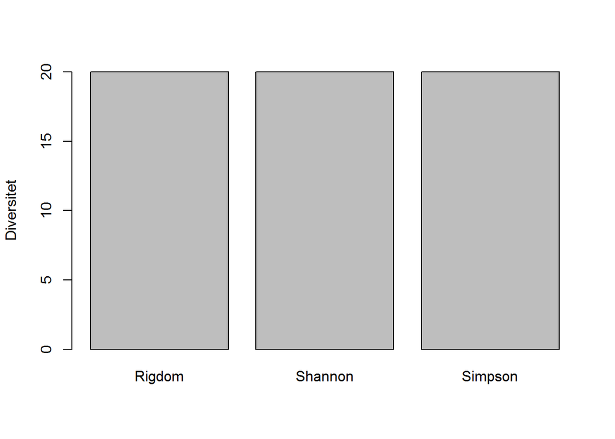

Men hvis vi ikke har lige stor abundans af alle arter får vi en mindre effektiv rigdom ved at bruge diversitets indeks i forhold til artsrigdom. Så diversitetsindeks kan ses som en form for korrektion for forskellig abundans arterne imellem. Her har vi samme abundans af den største gruppe

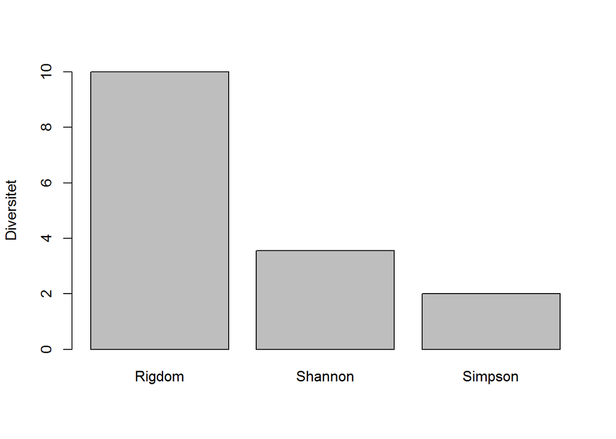

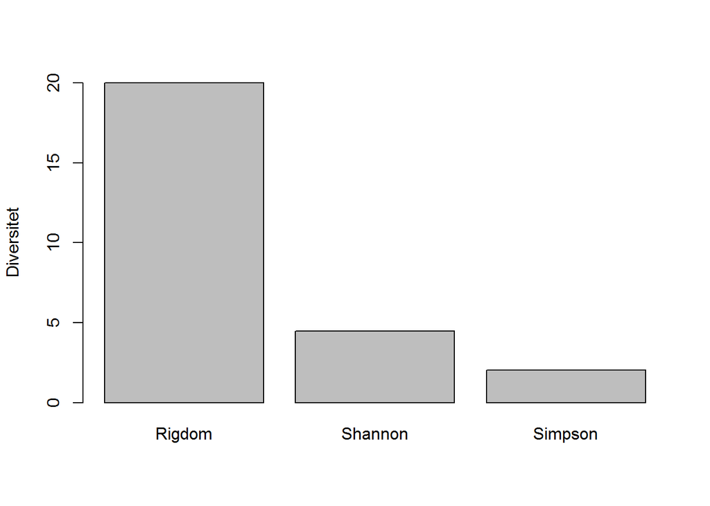

Her kan man se at den meget lave abundans for de fleste arter giver en betydeligt lavere diversitet for de to diversitets indeks end for artsrigdommen og at simpson penaliserer hårdere for lav abundans end shannon. Hvis vi tager en eksempel med mindre skævvridning

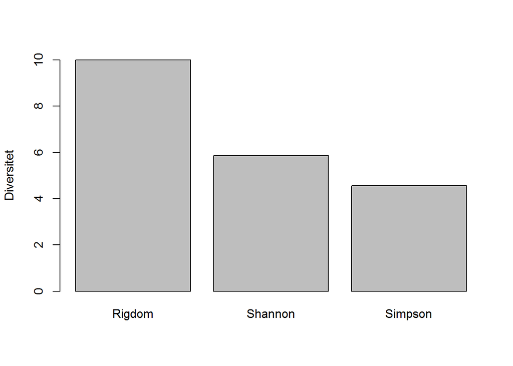

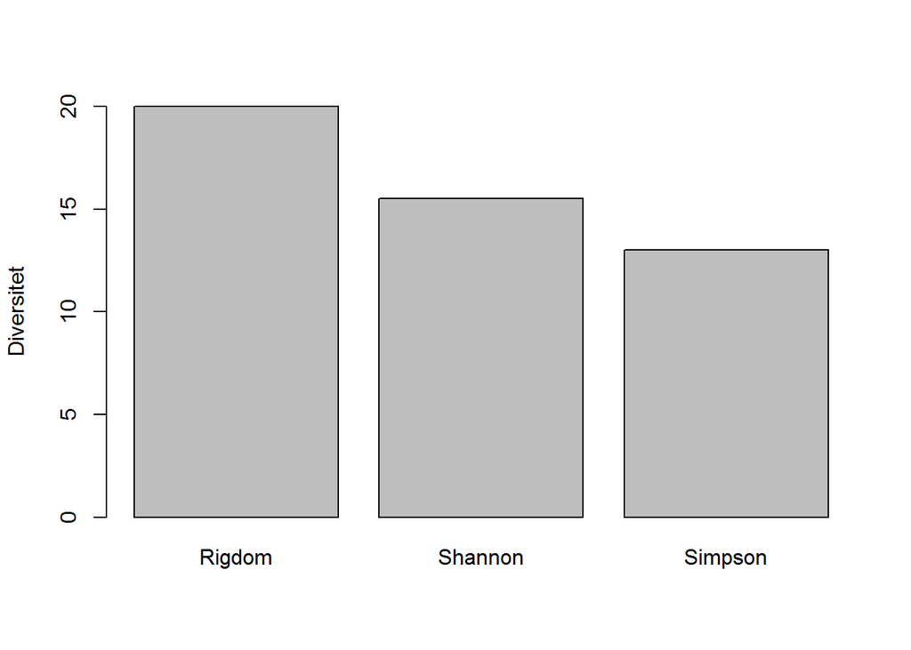

Her er der en minoritet som har mindre diversitet end resten ser vi det samme forhold som før.